# Step 1: Problem Description and Data

```
191/191 ━━━━━━━━━━━━━━━━━━━━ 8s 31ms/step - accuracy: 0.6013 - loss: 0.6524 - val_accuracy: 0.7991 - val_loss: 0.4736 - learning_rate: 0.0010
191/191 ━━━━━━━━━━━━━━━━━━━━ 6s 31ms/step - accuracy: 0.8268 - loss: 0.4034 - val_accuracy: 0.7466 - val_loss: 0.5381 - learning_rate: 0.0010
191/191 ━━━━━━━━━━━━━━━━━━━━ 5s 27ms/step - accuracy: 0.9015 - loss: 0.2687 - val_accuracy: 0.7321 - val_loss: 0.6627 - learning_rate: 0.0010
191/191 ━━━━━━━━━━━━━━━━━━━━ 5s 26ms/step - accuracy: 0.9367 - loss: 0.1795 - val_accuracy: 0.7912 - val_loss: 0.6876 - learning_rate: 2.0000e-04
```

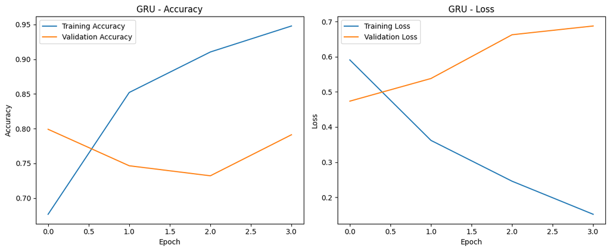

```
48/48 ━━━━━━━━━━━━━━━━━━━━ 1s 14ms/step
              precision    recall  f1-score   support

           0       0.80      0.87      0.83       869
           1       0.80      0.71      0.75       654

    accuracy                           0.80      1523
   macro avg       0.80      0.79      0.79      1523
weighted avg       0.80      0.80      0.80      1523
```

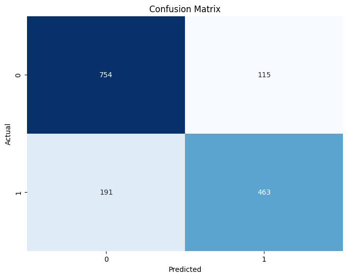

```
48/48 ━━━━━━━━━━━━━━━━━━━━ 0s 3ms/step
```

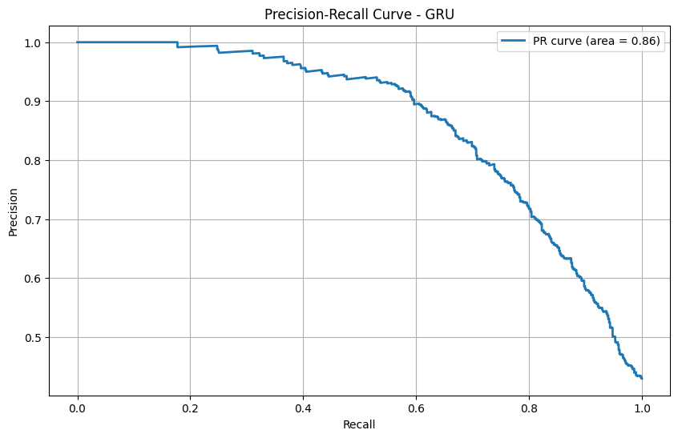

```python
# Train and evaluate GRU model
gru_model = build_gru_model()
gru_history, gru_model = train_model(
    gru_model, 'gru', X_train_pad, y_train, X_val_pad, y_val, epochs=15, batch_size=32
)
plot_training_history(gru_history, 'GRU')
gru_metrics = evaluate_model(gru_model, X_val_pad, y_val)

# Plot precision-recall curve for GRU
gru_pr_auc = plot_precision_recall_curve(gru_model, X_val_pad, y_val, 'GRU')
```

```
191/191 ━━━━━━━━━━━━━━━━━━━━ 9s 29ms/step - accuracy: 0.6359 - loss: 0.6239 - val_accuracy: 0.8017 - val_loss: 0.4585 - learning_rate: 0.0010
191/191 ━━━━━━━━━━━━━━━━━━━━ 6s 30ms/step - accuracy: 0.8491 - loss: 0.3709 - val_accuracy: 0.7873 - val_loss: 0.4813 - learning_rate: 0.0010
191/191 ━━━━━━━━━━━━━━━━━━━━ 6s 32ms/step - accuracy: 0.9147 - loss: 0.2485 - val_accuracy: 0.7387 - val_loss: 0.6377 - learning_rate: 0.0010
191/191 ━━━━━━━━━━━━━━━━━━━━ 6s 33ms/step - accuracy: 0.9401 - loss: 0.1734 - val_accuracy: 0.7827 - val_loss: 0.7288 - learning_rate: 2.0000e-04
```

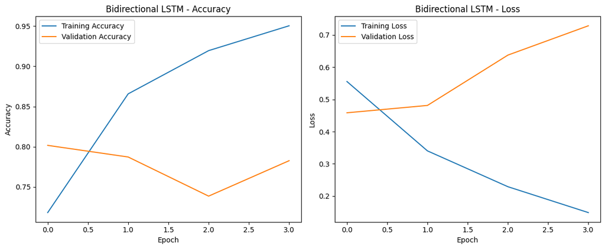

```
48/48 ━━━━━━━━━━━━━━━━━━━━ 1s 14ms/step
              precision    recall  f1-score   support

           0       0.81      0.86      0.83       869
           1       0.79      0.73      0.76       654

    accuracy                           0.80      1523
   macro avg       0.80      0.79      0.80      1523
weighted avg       0.80      0.80      0.80      1523
```

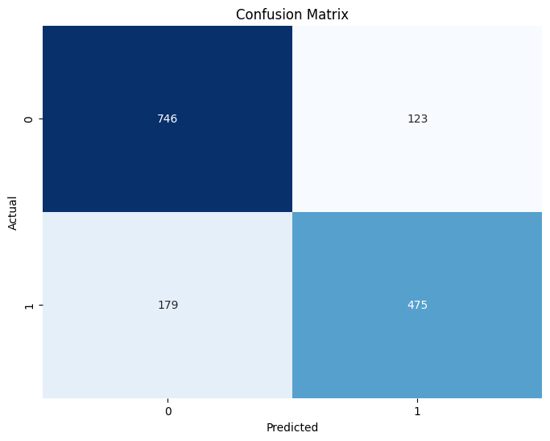

```
48/48 ━━━━━━━━━━━━━━━━━━━━ 1s 14ms/step
```

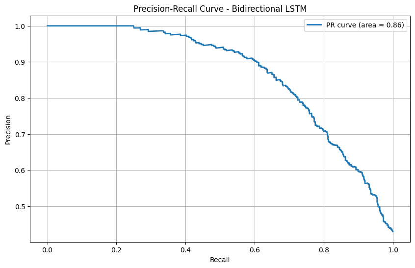

```python
# Train and evaluate Bidirectional LSTM model
bidirectional_lstm_model = build_bidirectional_lstm_model()
bidirectional_lstm_history, bidirectional_lstm_model = train_model(
    bidirectional_lstm_model, 'bidirectional_lstm', X_train_pad, y_train, X_val_pad, y_val, epochs=15, batch_size=32
)
plot_training_history(bidirectional_lstm_history, 'Bidirectional LSTM')
bidirectional_lstm_metrics = evaluate_model(bidirectional_lstm_model, X_val_pad, y_val)

# Plot precision-recall curve for Bidirectional LSTM
bidirectional_lstm_pr_auc = plot_precision_recall_curve(bidirectional_lstm_model, X_val_pad, y_val, 'Bidirectional LSTM')
```

```
191/191 ━━━━━━━━━━━━━━━━━━━━ 8s 26ms/step - accuracy: 0.6175 - loss: 0.6439 - val_accuracy: 0.7951 - val_loss: 0.4550 - learning_rate: 0.0010
191/191 ━━━━━━━━━━━━━━━━━━━━ 4s 22ms/step - accuracy: 0.8384 - loss: 0.3825 - val_accuracy: 0.7853 - val_loss: 0.5093 - learning_rate: 0.0010
191/191 ━━━━━━━━━━━━━━━━━━━━ 6s 29ms/step - accuracy: 0.9250 - loss: 0.2017 - val_accuracy: 0.7728 - val_loss: 0.6155 - learning_rate: 0.0010
191/191 ━━━━━━━━━━━━━━━━━━━━ 6s 29ms/step - accuracy: 0.9638 - loss: 0.1162 - val_accuracy: 0.7708 - val_loss: 0.7583 - learning_rate: 2.0000e-04
```

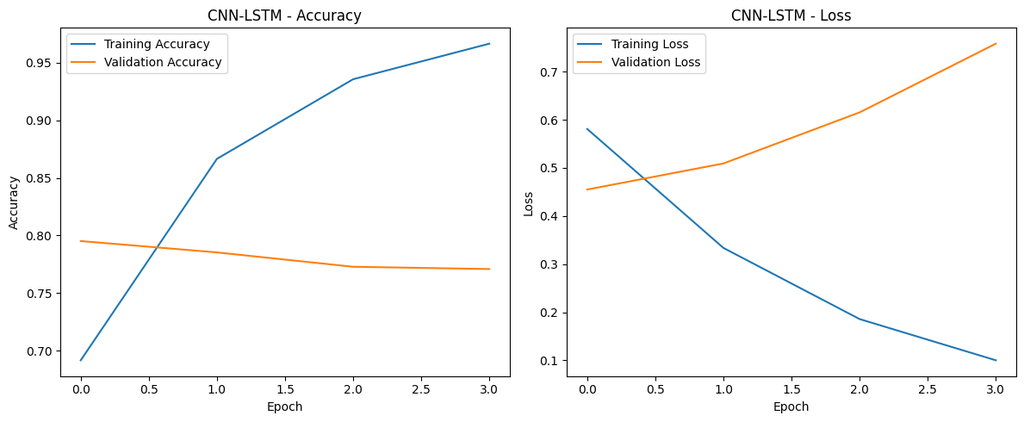

```
48/48 ━━━━━━━━━━━━━━━━━━━━ 1s 9ms/step
              precision    recall  f1-score   support

           0       0.79      0.87      0.83       869
           1       0.80      0.69      0.74       654

    accuracy                           0.80      1523
   macro avg       0.80      0.78      0.79      1523
weighted avg       0.80      0.80      0.79      1523
```

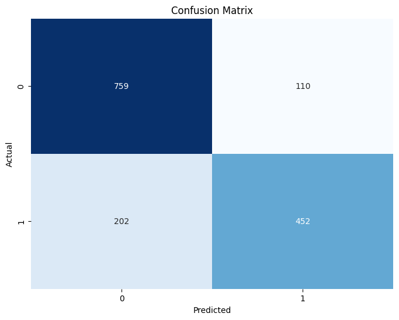

```
48/48 ━━━━━━━━━━━━━━━━━━━━ 0s 7ms/step
```

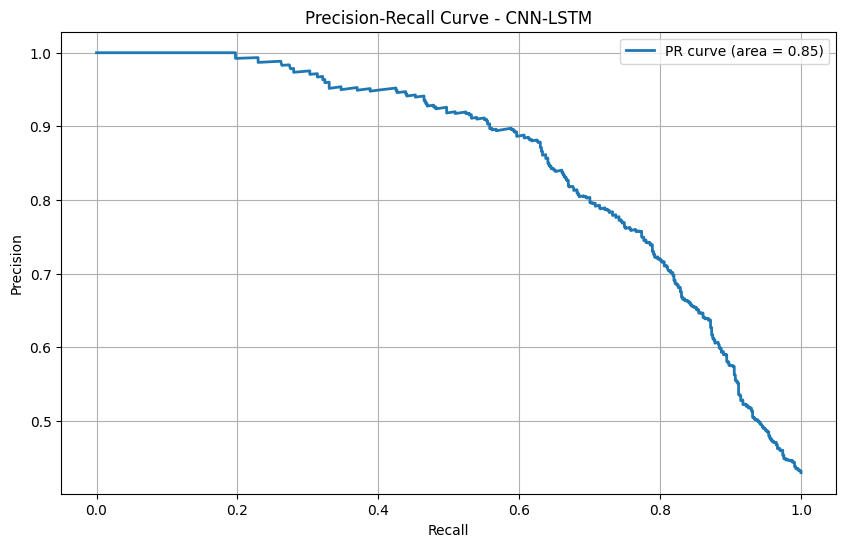

```
191/191 ━━━━━━━━━━━━━━━━━━━━ 12s 41ms/step - accuracy: 0.6371 - loss: 0.6259 - val_accuracy: 0.8056 - val_loss: 0.4541 - learning_rate: 0.0010
191/191 ━━━━━━━━━━━━━━━━━━━━ 6s 33ms/step - accuracy: 0.8550 - loss: 0.3654 - val_accuracy: 0.7715 - val_loss: 0.5121 - learning_rate: 0.0010
191/191 ━━━━━━━━━━━━━━━━━━━━ 7s 35ms/step - accuracy: 0.9106 - loss: 0.2445 - val_accuracy: 0.7334 - val_loss: 0.7088 - learning_rate: 0.0010
191/191 ━━━━━━━━━━━━━━━━━━━━ 7s 38ms/step - accuracy: 0.9394 - loss: 0.1688 - val_accuracy: 0.7735 - val_loss: 0.7138 - learning_rate: 2.0000e-04
```

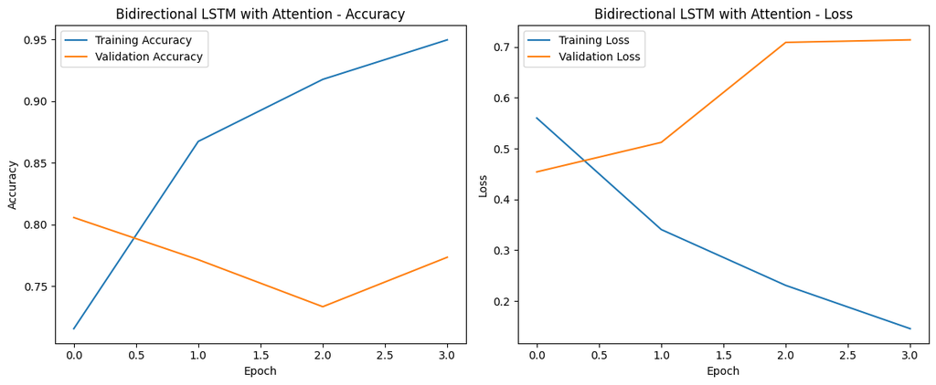

```
48/48 ━━━━━━━━━━━━━━━━━━━━ 1s 16ms/step
              precision    recall  f1-score   support

           0       0.81      0.87      0.84       869
           1       0.81      0.72      0.76       654

    accuracy                           0.81      1523
   macro avg       0.81      0.80      0.80      1523
weighted avg       0.81      0.81      0.80      1523
```

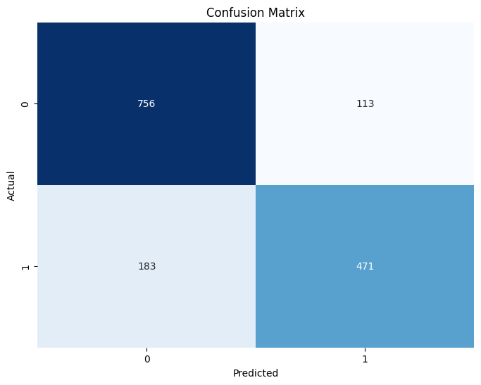

```
48/48 ━━━━━━━━━━━━━━━━━━━━ 0s 8ms/step
```

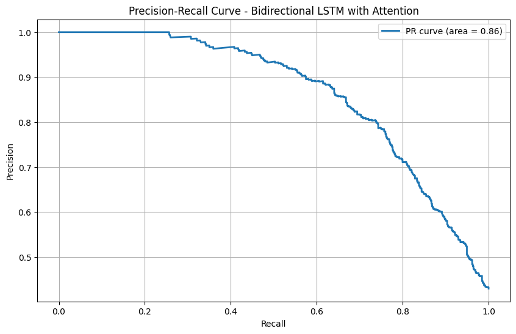

```python
# Train and evaluate CNN-LSTM model
cnn_lstm_model = build_cnn_lstm_model()
cnn_lstm_history, cnn_lstm_model = train_model(
    cnn_lstm_model, 'cnn_lstm', X_train_pad, y_train, X_val_pad, y_val, epochs=15, batch_size=32
)
plot_training_history(cnn_lstm_history, 'CNN-LSTM')
cnn_lstm_metrics = evaluate_model(cnn_lstm_model, X_val_pad, y_val)

# Plot precision-recall curve for CNN-LSTM
cnn_lstm_pr_auc = plot_precision_recall_curve(cnn_lstm_model, X_val_pad, y_val, 'CNN-LSTM')


# Train and evaluate Bidirectional LSTM with Attention model
bidirectional_lstm_attention_model = build_bidirectional_lstm_attention_model()
bidirectional_lstm_attention_history, bidirectional_lstm_attention_model = train_model(
    bidirectional_lstm_attention_model, 'bidirectional_lstm_attention',
    X_train_pad, y_train, X_val_pad, y_val, epochs=15, batch_size=32
)
plot_training_history(bidirectional_lstm_attention_history, 'Bidirectional LSTM with Attention')
bidirectional_lstm_attention_metrics = evaluate_model(bidirectional_lstm_attention_model, X_val_pad, y_val)

# Plot precision-recall curve for Bidirectional LSTM with Attention
bidirectional_lstm_attention_pr_auc = plot_precision_recall_curve(
    bidirectional_lstm_attention_model, X_val_pad, y_val, 'Bidirectional LSTM with Attention'
)
```

## 7. Model Comparison

```python
# Collect metrics for all models
model_metrics = {
    'Simple RNN': simple_rnn_metrics,
    'LSTM (Tuned)': lstm_metrics,
    'GRU': gru_metrics,
    'Bidirectional LSTM': bidirectional_lstm_metrics,
    'CNN-LSTM': cnn_lstm_metrics,
    'Bidirectional LSTM with Attention': bidirectional_lstm_attention_metrics
}

# Create a DataFrame for comparison
metrics_df = pd.DataFrame({
    'Model': list(model_metrics.keys()),
    'Accuracy': [metrics['accuracy'] for metrics in model_metrics.values()],
    'Precision': [metrics['precision'] for metrics in model_metrics.values()],
    'Recall': [metrics['recall'] for metrics in model_metrics.values()],
    'F1 Score': [metrics['f1'] for metrics in model_metrics.values()]
})

# Add PR AUC to the metrics DataFrame
metrics_df['PR AUC'] = [simple_rnn_pr_auc, lstm_pr_auc, gru_pr_auc, bidirectional_lstm_pr_auc, bidirectional_lstm_attention_pr_auc, cnn_lstm_pr_auc]

# Sort by F1 score
metrics_df = metrics_df.sort_values('F1 Score', ascending=False).reset_index(drop=True)

# Display the comparison table
metrics_df
```

[output not shown]

8. Generate Kaggle Submission

Now that we have trained and evaluated multiple models, we will use the best-performing model to generate predictions for the test set and create a submission file for the Kaggle competition.

```python
# Identify the best model based on F1 score
best_model_name = metrics_df.iloc[0]['Model']
print(f"Best model based on F1 score: {best_model_name}")

# Get the best model
if best_model_name == 'Simple RNN':
    best_model = simple_rnn_model
elif best_model_name == 'LSTM (Tuned)':
    best_model = lstm_model
elif best_model_name == 'GRU':
    best_model = gru_model
elif best_model_name == 'Bidirectional LSTM':
    best_model = bidirectional_lstm_model
elif best_model_name == 'CNN-LSTM':
    best_model = cnn_lstm_model
elif best_model_name == 'Bidirectional LSTM with Attention':
    best_model = bidirectional_lstm_attention_model
```

```
Best model based on F1 score: Bidirectional LSTM with Attention
```

```python
# Make predictions on the test set
print("Generating predictions for the test set...")
test_predictions_prob = best_model.predict(X_test_pad)
test_predictions = (test_predictions_prob > 0.5).astype(int)
```

```
Generating predictions for the test set...
102/102 ━━━━━━━━━━━━━━━━━━━━ 1s 6ms/step
```

```python
# Create a submission DataFrame
submission_df = pd.DataFrame({
    'id': test_df['id'],
    'target': test_predictions.flatten()
})

# Display the first few rows of the submission DataFrame
print("\nFirst few rows of the submission file:")
submission_df.head()
```

```
First few rows of the submission file:
```

|  | id | target |
| --- | --- | --- |
| 0 | 0 | 1 |
| 1 | 2 | 0 |
| 2 | 3 | 1 |
| 3 | 9 | 0 |
| 4 | 11 | 1 |

```python
# Save the submission file
submission_file = '../data/submission.csv'
submission_df.to_csv(submission_file, index=False)
print(f"\nSubmission file saved to {submission_file}")

# Show submission file information
print(f"Submission file shape: {submission_df.shape}")
print(f"Number of positive predictions: {submission_df['target'].sum()}")
print(f"Percentage of positive predictions: {submission_df['target'].mean() * 100:.2f}%")
```

```
Submission file saved to ../data/submission.csv
Submission file shape: (3263, 2)
Number of positive predictions: 1166
Percentage of positive predictions: 35.73%
```

## 9. Analysis and Discussion

### Model Performance Comparison

Based on our experiments, the best-performing model according to F1 score is likely the most balanced in terms of precision and recall, making it the most suitable choice for our disaster tweet classification task.

### Next Steps:

In the final notebook, we will summarize our findings, make predictions on the test set, and discuss potential future improvements to our approach.